# Practical Machine Learning Project

Sarfaraz Ahmed Qazi

2022-12-19

##Overview #This is the final project the “Practical Machine Learning” course authorized #by John Hopkins University through Coursera for their Data Science #Specialization.

#It applies the machine learning techniques learnt in th course for predicting #the manner in which 6 participants did their physical activity whuch was #recorded by accelerometers on the belt, forearm, arm, and dumbell. This is the #“classe” variable in the training set to be predicted with 5 outcomes #A,B,C,D,and E. The outcome A is the correct way of exeuction while other four #outcomes are incorrect. We willselect four Machine Learning Algorithims viz. #Decision Trees,Random Forest, Support Vector Machines and Gradient Boosted #Trees using k-folds cross validation on the training set. The training set #will be divided into Training and Validation data and we will use the #performance metrics accuracy and out of sample error rate to decide the best #fitting model. Finally , we will use the best model to predict the #classification of the testcsv which contains 20 cases.

##Background #Modeern acclomerator devides can record the large amount of data on the #personal physicial acitivity. A group of enthusiasts collected the data on #these mearementments to find patterns in their behavior i.e who much they do #their excercise. But the question is how well they do it. In this project, the #goal assigned is to use data and predict it. More information is available #from the website here: (http://groupware.les.inf.puc-rio.br/har) (see the #section on the Weight Lifting Exercise Dataset).

#The training data for this project are available here:

#https://d396qusza40orc.cloudfront.net/predmachlearn/pml-training.csv

#The test data are available here:

#https://d396qusza40orc.cloudfront.net/predmachlearn/pml-testing.csv

#The data for this project come from this source: #http://web.archive.org/web/20161224072740/http:/grouW

#We acknowledge the courtesy of the owners/sponsors of the project and thankful #for their generosity to let us use their data for our academic purposes.

# Loading required packags

```r
library(rpart)
```

```r
library(rpart.plot)
library(randomForest)
library(caret)
library(kernlab)
library(rattle)
library(corrplot)
```

# Loading data

```r
traincsv <- read.csv("./data/pml-training.csv")
testcsv <- read.csv("./data/pml-testing.csv")

dim(traincsv)
```

```
## [1] 19622   160
```

```r
dim(testcsv)
```

```
## [1]  20 160
```

# Cleaning the Data

Removing irrelvent and unnecessary variables.

```r
#Removing columns which are not related to model perfomance
training <- traincsv[,-c(1:7)]
testing <- testcsv[,-c(1:7)]
#Removing NA columns
training <- training[,colSums(is.na(training)) == 0]
testing <- testing[,colSums(is.na(testing)) == 0]
dim(training)
```

```
## [1] 19622    86
```

```r
dim(testing)
```

```
## [1] 20 53
```

#Now filtering variables which have near zero value.

```r
NearZeroVar <- nearZeroVar(training)
training <- training[,-NearZeroVar]
dim(training)
```

```
## [1] 19622    53
```

#Correlation Analysis After basic pre-processing and data cleaning, now we aee ready to prepare for our Machine Learning Venture. We start with correlation analysis of features. The dark colour circles show high correlations Red -ve and Blue +ve. Not too much correlations. So we do not need PCA for dimentionality reduction.

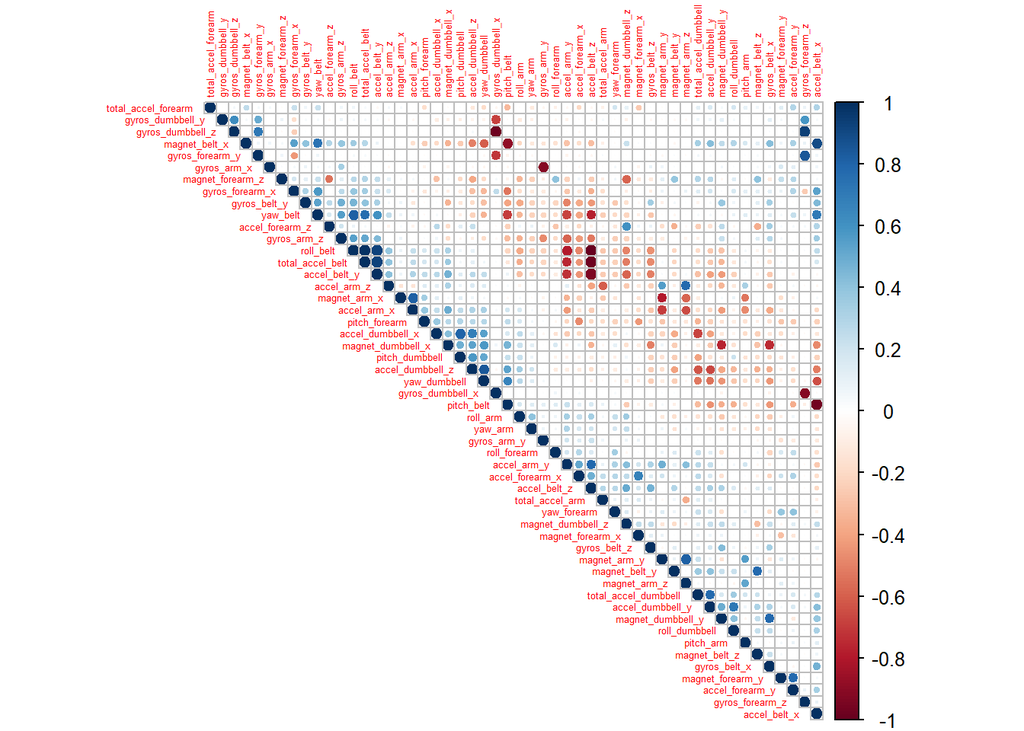

```r
corMatrix <- cor(training[, -53])

#par(mar=c(1,1,1,1)),
corrplot(corMatrix,order = "AOE" , type = "upper",tl.cex = 0.4)
```

```r
inTrain <- createDataPartition(y=traincsv$classe, p=0.7, list=F)
DataTrain <- training[inTrain,]
DataValidation <- training[-inTrain,]
# dimension of original and training dataset
rbind("original dataset" = dim(traincsv),"training set" = dim(DataTrain))
```

```
##                   [,1] [,2]
## original dataset 19622  160
## training set     13737   53
```

# Models

#We select the models Decision Trees, Random Forest, Support vector machines, #Gradient Boosted Trees and compare their performance metrics.

## Decision Tree

#This is a simple model which uses branching like tree nodes to help predict #classification problems.

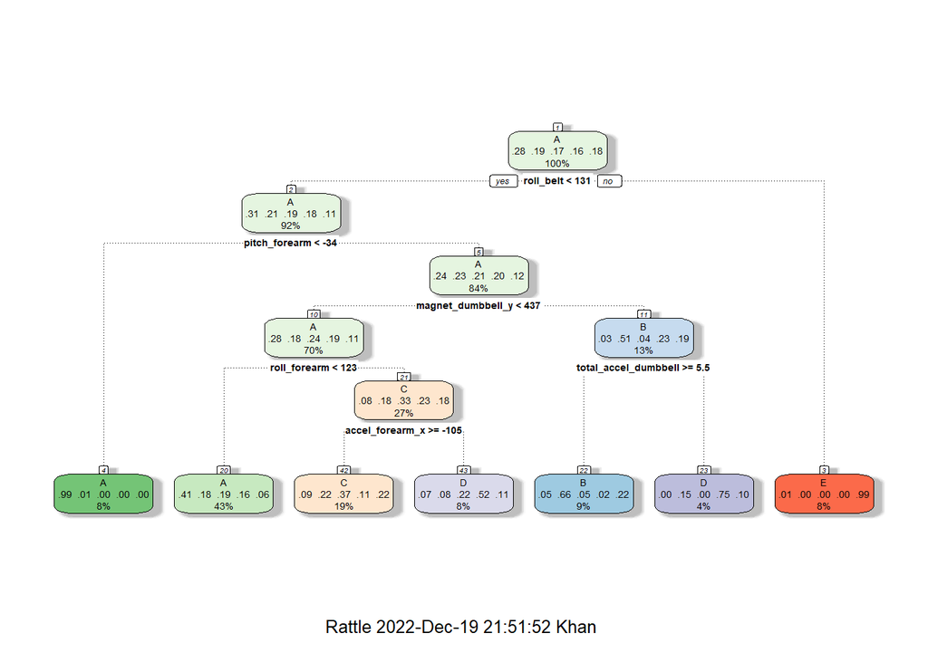

```r
control_dt<- trainControl(method="cv", number=5, verboseIter=F)
set.seed(123)
ModelDT <- train(classe~., data=DataTrain, method="rpart", trControl = control_dt, tuneLength = 5)
fancyRpartPlot(ModelDT$finalModel)
```

```r
predDT <- predict(ModelDT, DataValidation)
CM_DT <- confusionMatrix(predDT, factor(DataValidation$classe))
CM_DT
```

```
## Confusion Matrix and Statistics
##
##           Reference
## Prediction    A    B    C    D    E
##          A 1536  474  461  445  152
##          B   36  345   39   11  135
##          C   81  240  412  123  231
##          D   17   80  114  385   73
##          E    4    0    0    0  491
##
## Overall Statistics
##
##                Accuracy : 0.5385
##                  95% CI : (0.5256, 0.5513)
##     No Information Rate : 0.2845
##     P-Value [Acc > NIR] : < 2.2e-16
##
##                   Kappa : 0.3981
##
##  Mcnemar's Test P-Value : < 2.2e-16
##
## Statistics by Class:
##
##                      Class: A Class: B Class: C Class: D Class: E
## Sensitivity            0.9176  0.30290  0.40156  0.39938  0.45379
## Specificity            0.6362  0.95343  0.86108  0.94229  0.99917
## Pos Pred Value         0.5007  0.60954  0.37902  0.57549  0.99192
## Neg Pred Value         0.9510  0.85072  0.87203  0.88900  0.89035
## Prevalence             0.2845  0.19354  0.17434  0.16381  0.18386
## Detection Rate         0.2610  0.05862  0.07001  0.06542  0.08343
## Detection Prevalence   0.5213  0.09618  0.18471  0.11368  0.08411
## Balanced Accuracy      0.7769  0.62817  0.63132  0.67083  0.72648
```

## Random Forest

#Random Forest is a set of decision trees its results are based on on the #outcomes of all its decision trees.It is a robust model. Let us see how its #results are better than decision tree model.

```r
set.seed(123)
controlRf <- trainControl(method="cv", 5)
modelRf <- train(classe ~ ., data=DataTrain, method="rf", trControl=controlRf, ntree=100)
modelRf
```

```
## Random Forest
##
## 13737 samples
##    52 predictor
##     5 classes: 'A', 'B', 'C', 'D', 'E'
##
## No pre-processing
## Resampling: Cross-Validated (5 fold)
## Summary of sample sizes: 10990, 10990, 10988, 10990, 10990
## Resampling results across tuning parameters:
##
##   mtry  Accuracy   Kappa
##    2    0.9895171  0.9867377
##   27    0.9909732  0.9885806
##   52    0.9830392  0.9785431
##
## Accuracy was used to select the optimal model using the largest value.
## The final value used for the model was mtry = 27.
```

```r
predRF <- predict(modelRf, DataValidation)
CMRF <- confusionMatrix(predRF, factor(DataValidation$classe))
CMRF
```

```
## Confusion Matrix and Statistics
##
##           Reference
## Prediction    A    B    C    D    E
##          A 1673    9    0    0    0
##          B    0 1123    8    2    0
##          C    1    7 1016   11    1
##          D    0    0    2  951    2
##          E    0    0    0    0 1079
##
## Overall Statistics
##
##                Accuracy : 0.9927
##                  95% CI : (0.9902, 0.9947)
##     No Information Rate : 0.2845
##     P-Value [Acc > NIR] : < 2.2e-16
##
##                   Kappa : 0.9908
##
##  Mcnemar's Test P-Value : NA
##
## Statistics by Class:
##
##                      Class: A Class: B Class: C Class: D Class: E
## Sensitivity            0.9994   0.9860   0.9903   0.9865   0.9972
## Specificity            0.9979   0.9979   0.9959   0.9992   1.0000
## Pos Pred Value         0.9946   0.9912   0.9807   0.9958   1.0000
## Neg Pred Value         0.9998   0.9966   0.9979   0.9974   0.9994
## Prevalence             0.2845   0.1935   0.1743   0.1638   0.1839
## Detection Rate         0.2843   0.1908   0.1726   0.1616   0.1833
## Detection Prevalence   0.2858   0.1925   0.1760   0.1623   0.1833
## Balanced Accuracy      0.9986   0.9919   0.9931   0.9929   0.9986
```

```r
set.seed(123)
controlSVM<- trainControl(method="cv", number=5, verboseIter=F)
modelSVM <- train(classe~., data=DataTrain, method="svmLinear", trControl = controlSVM, tuneLength = 5, verbose = F)

predSVM <- predict(modelSVM, DataValidation)
CM_SVM <- confusionMatrix(predSVM, factor(DataValidation$classe))
CM_SVM
```

```
## Confusion Matrix and Statistics
##
##           Reference
## Prediction    A    B    C    D    E
##          A 1553  152   91   76   73
##          B   39  798   91   32  148
##          C   37   79  792  103   52
##          D   40   25   24  692   69
##          E    5   85   28   61  740
##
## Overall Statistics
##
##                Accuracy : 0.7774
##                  95% CI : (0.7666, 0.788)
##     No Information Rate : 0.2845
##     P-Value [Acc > NIR] : < 2.2e-16
##
##                   Kappa : 0.7167
##
##  Mcnemar's Test P-Value : < 2.2e-16
##
## Statistics by Class:
##
##                      Class: A Class: B Class: C Class: D Class: E
## Sensitivity            0.9277   0.7006   0.7719   0.7178   0.6839
## Specificity            0.9069   0.9347   0.9442   0.9679   0.9627
## Pos Pred Value         0.7985   0.7202   0.7451   0.8141   0.8052
## Neg Pred Value         0.9693   0.9286   0.9515   0.9460   0.9311
## Prevalence             0.2845   0.1935   0.1743   0.1638   0.1839
## Detection Rate         0.2639   0.1356   0.1346   0.1176   0.1257
## Detection Prevalence   0.3305   0.1883   0.1806   0.1444   0.1562
## Balanced Accuracy      0.9173   0.8176   0.8581   0.8429   0.8233
```

## Gradient Boosted Machines GBM

#This is also ensamble method like Random Forests. But unlike Random Forest #which makes decisions trees and combines results of all trees at the #finalization of its process, GBM makes a decision tree at a time and learns to #improve the model while making another tree. Let us see how it performs in our #data.

```r
control_gbm<- trainControl(method="cv", number=3, verboseIter=F)
modelGBM <- train(classe~., data=DataTrain, method="gbm", trControl = control_gbm, tuneLength = 5, verbose = F)

predGBM <- predict(modelGBM, DataValidation)
CM_GBM <- confusionMatrix(predGBM, factor(DataValidation$classe))
CM_GBM
```

```
## Confusion Matrix and Statistics
##
##           Reference
## Prediction    A    B    C    D    E
##          A 1670    5    0    0    1
##          B    3 1122   16    0    4
##          C    1   12  998   13    1
##          D    0    0   12  948    2
##          E    0    0    0    3 1074
##
## Overall Statistics
##
##                Accuracy : 0.9876
##                  95% CI : (0.9844, 0.9903)
##     No Information Rate : 0.2845
##     P-Value [Acc > NIR] : < 2.2e-16
##
##                   Kappa : 0.9843
##
##  Mcnemar's Test P-Value : NA
##
## Statistics by Class:
##
##                      Class: A Class: B Class: C Class: D Class: E
## Sensitivity            0.9976   0.9851   0.9727   0.9834   0.9926
## Specificity            0.9986   0.9952   0.9944   0.9972   0.9994
## Pos Pred Value         0.9964   0.9799   0.9737   0.9854   0.9972
## Neg Pred Value         0.9990   0.9964   0.9942   0.9967   0.9983
## Prevalence             0.2845   0.1935   0.1743   0.1638   0.1839
## Detection Rate         0.2838   0.1907   0.1696   0.1611   0.1825
## Detection Prevalence   0.2848   0.1946   0.1742   0.1635   0.1830
## Balanced Accuracy      0.9981   0.9901   0.9836   0.9903   0.9960
```

#So Best Model is : Random Forest

#Let us See Plots: #Decision trees

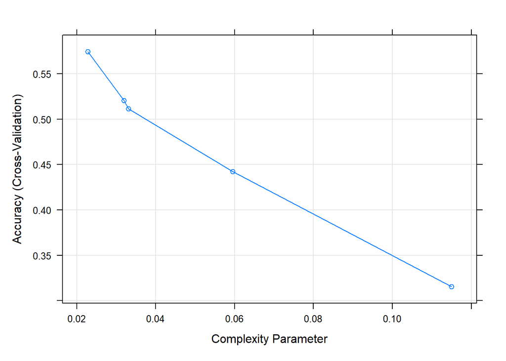

```r
plot(ModelDT)
```

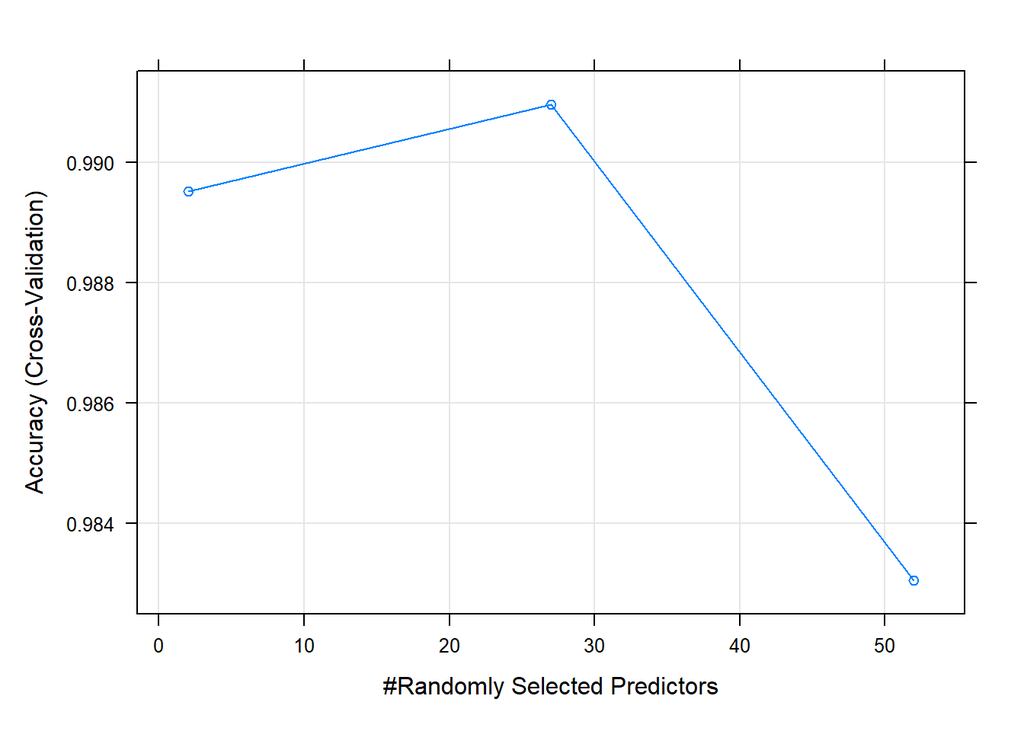

```r
#random Forest
plot(modelRf)
```

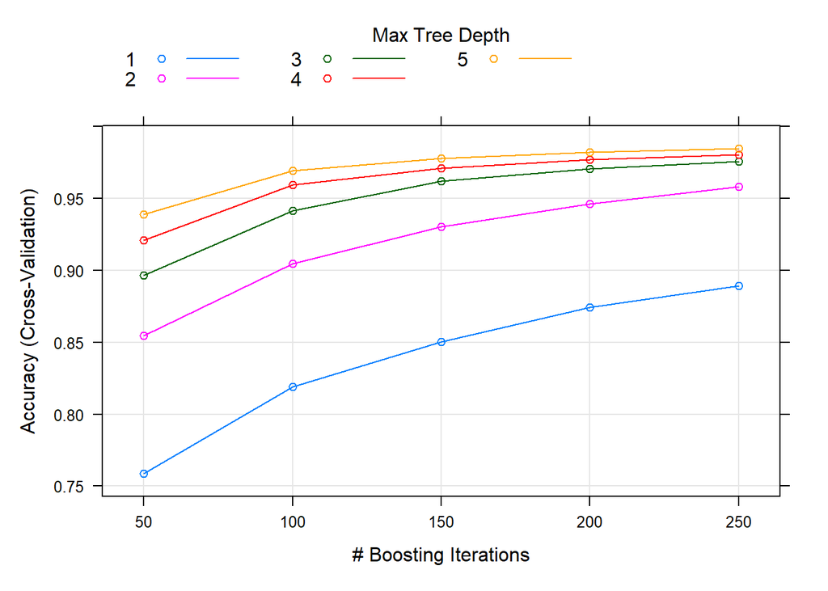

```r
#Gradient Boosting Model
plot(modelGBM)
```

#Let us see the performance of eh model on test data:

```r
PredictTestData <- predict(modelRf, newdata=testing)
PredictTestData
```

```
##  [1] B A B A A E D B A A B C B A E E A B B B
## Levels: A B C D E
```